# Movie Data Exploration

## Preliminary Wrangling

This document explores a dataset containing revenue,budget and users rating for approximately 11000 movies(TMDb).

## Data Wrangling

```python
# import all packages and set plots to be embedded inline
import numpy as np
import pandas as pd
import matplotlib.pyplot as plt
import seaborn as sns
%matplotlib inline
```

```python
tmdb_df = pd.read_csv('tmdb-movies.csv')
tmdb_df.info()
```

```
<class 'pandas.core.frame.DataFrame'>
RangeIndex: 10866 entries, 0 to 10865
Data columns (total 21 columns):
 #   Column                Non-Null Count  Dtype
---  ------                --------------  -----
 0   id                    10866 non-null  int64
 1   imdb_id               10856 non-null  object
 2   popularity            10866 non-null  float64
 3   budget                10866 non-null  int64
 4   revenue               10866 non-null  int64
 5   original_title        10866 non-null  object
 6   cast                  10790 non-null  object
 7   homepage              2936 non-null   object
 8   director              10822 non-null  object
 9   tagline               8042 non-null   object
 10  keywords              9373 non-null   object
 11  overview              10862 non-null  object
 12  runtime               10866 non-null  int64
 13  genres                10843 non-null  object
 14  production_companies  9836 non-null   object
 15  release_date          10866 non-null  object
 16  vote_count            10866 non-null  int64
 17  vote_average          10866 non-null  float64
 18  release_year          10866 non-null  int64
 19  budget_adj            10866 non-null  float64
 20  revenue_adj           10866 non-null  float64
dtypes: float64(4), int64(6), object(11)
memory usage: 1.7+ MB
```

```python
tmdb_df.shape
```

```
(10866, 21)
```

```python
tmdb_df.describe()
```

|  | id | popularity | budget | revenue | runtime | vote_count | vote_average | release_year | budget_adj | revenue_adj |
| --- | --- | --- | --- | --- | --- | --- | --- | --- | --- | --- |
| count | 10866.000000 | 10866.000000 | 1.086600e+04 | 1.086600e+04 | 10866.000000 | 10866.000000 | 10866.000000 | 10866.000000 | 1.086600e+04 | 1.086600e+04 |
| mean | 66064.177434 | 0.646441 | 1.462570e+07 | 3.982332e+07 | 102.070863 | 217.389748 | 5.974922 | 2001.322658 | 1.755104e+07 | 5.136436e+07 |
| std | 92130.136561 | 1.000185 | 3.091321e+07 | 1.170035e+08 | 31.381405 | 575.619058 | 0.935142 | 12.812941 | 3.430616e+07 | 1.446325e+08 |
| min | 5.000000 | 0.000065 | 0.000000e+00 | 0.000000e+00 | 0.000000 | 10.000000 | 1.500000 | 1960.000000 | 0.000000e+00 | 0.000000e+00 |
| 25% | 10596.250000 | 0.207583 | 0.000000e+00 | 0.000000e+00 | 90.000000 | 17.000000 | 5.400000 | 1995.000000 | 0.000000e+00 | 0.000000e+00 |
| 50% | 20669.000000 | 0.383856 | 0.000000e+00 | 0.000000e+00 | 99.000000 | 38.000000 | 6.000000 | 2006.000000 | 0.000000e+00 | 0.000000e+00 |
| 75% | 75610.000000 | 0.713817 | 1.500000e+07 | 2.400000e+07 | 111.000000 | 145.750000 | 6.600000 | 2011.000000 | 2.085325e+07 | 3.369710e+07 |
| max | 417859.000000 | 32.985763 | 4.250000e+08 | 2.781506e+09 | 900.000000 | 9767.000000 | 9.200000 | 2015.000000 | 4.250000e+08 | 2.827124e+09 |

```python
#Create a list of columns to be deleted
cols_to_del = ['id', 'imdb_id','tagline', 'homepage', 'keywords', 'overview', 'production_companies','director']

# delete irrevelant columns
tmdb_df = tmdb_df.drop(cols_to_del,1)
tmdb_df.tail()
```

|  | popularity | budget | revenue | original_title | cast | runtime | genres | release_date | vote_count | vote_average | release_year | budget_adj | revenue_adj |
| --- | --- | --- | --- | --- | --- | --- | --- | --- | --- | --- | --- | --- | --- |
| 10861 | 0.080598 | 0 | 0 | The Endless Summer | Michael Hynson\|Robert August\|Lord 'Tally Ho' B... | 95 | Documentary | 6/15/66 | 11 | 7.4 | 1966 | 0.000000 | 0.0 |
| 10862 | 0.065543 | 0 | 0 | Grand Prix | James Garner\|Eva Marie Saint\|Yves Montand\|Tosh... | 176 | Action\|Adventure\|Drama | 12/21/66 | 20 | 5.7 | 1966 | 0.000000 | 0.0 |
| 10863 | 0.065141 | 0 | 0 | Beregis Avtomobilya | Innokentiy Smoktunovskiy\|Oleg Efremov\|Georgi Z... | 94 | Mystery\|Comedy | 1/1/66 | 11 | 6.5 | 1966 | 0.000000 | 0.0 |
| 10864 | 0.064317 | 0 | 0 | What's Up, Tiger Lily? | Tatsuya Mihashi\|Akiko Wakabayashi\|Mie Hama\|Joh... | 80 | Action\|Comedy | 11/2/66 | 22 | 5.4 | 1966 | 0.000000 | 0.0 |
| 10865 | 0.035919 | 19000 | 0 | Manos: The Hands of Fate | Harold P. Warren\|Tom Neyman\|John Reynolds\|Dian... | 74 | Horror | 11/15/66 | 15 | 1.5 | 1966 | 127642.279154 | 0.0 |

```python
#Drop duplicates
tmdb_df.drop_duplicates(keep = 'first',inplace=True)
tmdb_df.shape
```

```
(10865, 13)
```

```python
tmdb_df.info()
```

```
<class 'pandas.core.frame.DataFrame'>
Int64Index: 10865 entries, 0 to 10865
Data columns (total 13 columns):
 #   Column          Non-Null Count  Dtype
---  ------          --------------  -----
 0   popularity      10865 non-null  float64
 1   budget          10865 non-null  int64
 2   revenue         10865 non-null  int64
 3   original_title  10865 non-null  object
 4   cast            10789 non-null  object
 5   runtime         10865 non-null  int64
 6   genres          10842 non-null  object
 7   release_date    10865 non-null  object
 8   vote_count      10865 non-null  int64
 9   vote_average    10865 non-null  float64
 10  release_year    10865 non-null  int64
 11  budget_adj      10865 non-null  float64
 12  revenue_adj     10865 non-null  float64
dtypes: float64(4), int64(5), object(4)
memory usage: 1.2+ MB
```

```python
tmdb_df.dropna(inplace=True)
```

```python
tmdb_df.isnull().sum()
```

```
popularity        0
budget            0
revenue           0
original_title    0
cast              0
runtime           0
genres            0
release_date      0
vote_count        0
vote_average      0
release_year      0
budget_adj        0
revenue_adj       0
dtype: int64
```

```python
# Drop rows with Zero
tmdb_no_zero = tmdb_df.loc[(tmdb_df != 0).any(axis=1)]
```

```python
tmdb_no_zero.describe()
```

|  | popularity | budget | revenue | runtime | vote_count | vote_average | release_year | budget_adj | revenue_adj |
| --- | --- | --- | --- | --- | --- | --- | --- | --- | --- |
| count | 10767.000000 | 1.076700e+04 | 1.076700e+04 | 10767.000000 | 10767.000000 | 10767.000000 | 10767.000000 | 1.076700e+04 | 1.076700e+04 |
| mean | 0.650924 | 1.475532e+07 | 4.018610e+07 | 102.413393 | 219.137364 | 5.967549 | 2001.283459 | 1.770705e+07 | 5.183338e+07 |
| std | 1.003565 | 3.102387e+07 | 1.174783e+08 | 30.906009 | 577.964702 | 0.931426 | 12.815909 | 3.442339e+07 | 1.452125e+08 |
| min | 0.000065 | 0.000000e+00 | 0.000000e+00 | 0.000000 | 10.000000 | 1.500000 | 1960.000000 | 0.000000e+00 | 0.000000e+00 |
| 25% | 0.209957 | 0.000000e+00 | 0.000000e+00 | 90.000000 | 17.000000 | 5.400000 | 1995.000000 | 0.000000e+00 | 0.000000e+00 |
| 50% | 0.386062 | 0.000000e+00 | 0.000000e+00 | 99.000000 | 39.000000 | 6.000000 | 2006.000000 | 0.000000e+00 | 0.000000e+00 |
| 75% | 0.719253 | 1.600000e+07 | 2.476490e+07 | 112.000000 | 147.000000 | 6.600000 | 2011.000000 | 2.103337e+07 | 3.432264e+07 |
| max | 32.985763 | 4.250000e+08 | 2.781506e+09 | 900.000000 | 9767.000000 | 9.200000 | 2015.000000 | 4.250000e+08 | 2.827124e+09 |

```python
tmdb_df.release_date = pd.to_datetime(tmdb_df['release_date'])
```

```python
tmdb_df.info()
```

```
<class 'pandas.core.frame.DataFrame'>
Int64Index: 10767 entries, 0 to 10865
Data columns (total 13 columns):
 #   Column          Non-Null Count  Dtype
---  ------          --------------  -----
 0   popularity      10767 non-null  float64
 1   budget          10767 non-null  int64
 2   revenue         10767 non-null  int64
 3   original_title  10767 non-null  object
 4   cast            10767 non-null  object
 5   runtime         10767 non-null  int64
 6   genres          10767 non-null  object
 7   release_date    10767 non-null  datetime64[ns]
 8   vote_count      10767 non-null  int64
 9   vote_average    10767 non-null  float64
 10  release_year    10767 non-null  int64
 11  budget_adj      10767 non-null  float64
 12  revenue_adj     10767 non-null  float64
dtypes: datetime64[ns](1), float64(4), int64(5), object(3)
memory usage: 1.2+ MB
```

```python
#The figure for revenue_adj and budget_adj has an exponential component that are not easy to inteprete.I will divide by a million (1000000) to get the equivalent value in million $
tmdb_no_zero['budget in million dollar'] = tmdb_df['budget_adj']/1000000

tmdb_no_zero['revenue in million dollar']=tmdb_no_zero['revenue_adj']/1000000
tmdb_no_zero.head()
```

|  | popularity | budget | revenue | original_title | cast | runtime | genres | release_date | vote_count | vote_average | release_year | budget_adj | revenue_adj | budget in million dollar | revenue in million dollar |
| --- | --- | --- | --- | --- | --- | --- | --- | --- | --- | --- | --- | --- | --- | --- | --- |
| 0 | 32.985763 | 150000000 | 1513528810 | Jurassic World | Chris Pratt\|Bryce Dallas Howard\|Irrfan Khan\|Vi... | 124 | Action\|Adventure\|Science Fiction\|Thriller | 6/9/15 | 5562 | 6.5 | 2015 | 1.379999e+08 | 1.392446e+09 | 137.999939 | 1392.445893 |
| 1 | 28.419936 | 150000000 | 378436354 | Mad Max: Fury Road | Tom Hardy\|Charlize Theron\|Hugh Keays-Byrne\|Nic... | 120 | Action\|Adventure\|Science Fiction\|Thriller | 5/13/15 | 6185 | 7.1 | 2015 | 1.379999e+08 | 3.481613e+08 | 137.999939 | 348.161292 |
| 2 | 13.112507 | 110000000 | 295238201 | Insurgent | Shailene Woodley\|Theo James\|Kate Winslet\|Ansel... | 119 | Adventure\|Science Fiction\|Thriller | 3/18/15 | 2480 | 6.3 | 2015 | 1.012000e+08 | 2.716190e+08 | 101.199955 | 271.619025 |
| 3 | 11.173104 | 200000000 | 2068178225 | Star Wars: The Force Awakens | Harrison Ford\|Mark Hamill\|Carrie Fisher\|Adam D... | 136 | Action\|Adventure\|Science Fiction\|Fantasy | 12/15/15 | 5292 | 7.5 | 2015 | 1.839999e+08 | 1.902723e+09 | 183.999919 | 1902.723130 |
| 4 | 9.335014 | 190000000 | 1506249360 | Furious 7 | Vin Diesel\|Paul Walker\|Jason Statham\|Michelle ... | 137 | Action\|Crime\|Thriller | 4/1/15 | 2947 | 7.3 | 2015 | 1.747999e+08 | 1.385749e+09 | 174.799923 | 1385.748801 |

```python
tmdb_no_zero['budget in million dollar'].max()
```

```
425.0
```

# Exploratory Data Analysis

## Univariate Exploration

### Checking for movie budget in million distribution

```python
def myHistPlot(df,xVar,interval,figsize=[14,6],title=''):
    #Set intervals for bins
    bins=np.arange(df[xVar].min(),df[xVar].max()+interval,interval)
    #plot
    df[xVar].hist(bins=bins,grid=False,edgecolor='black',figsize=figsize);


    #for labels,add a space instead of underscore
    xVar=xVar.replace("_"," ")
    plt.title(f'Distribution of {xVar}{title}'.title(),fontsize=14,weight='bold')

    #Add x label and format it
    plt.xlabel(xVar.title(),fontsize =10,weight="bold")

    #Add y label and format it
    plt.ylabel('frequency'.title(),fontsize =10,weight="bold")
```

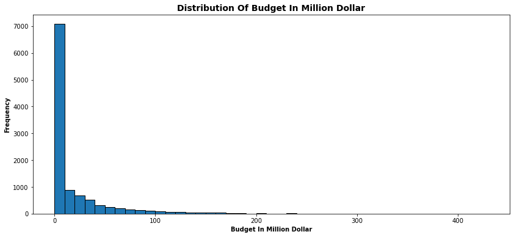

```python
# Call plot function (using all data)
myHistPlot(tmdb_no_zero,'budget in million dollar',10)
```

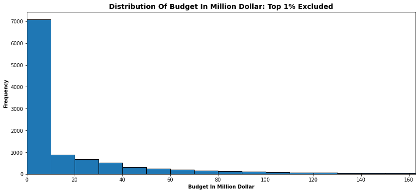

```python
# Call the plot function (using all data)
myHistPlot(tmdb_no_zero,'budget in million dollar',10,title=": Top 1% Excluded")
#Set upper bound x axis (99th percentile)
plt.axis([0,tmdb_no_zero['budget in million dollar'].quantile(0.99),None,None]);
```

Low budget films are more frequent (i.e More than 7000 movies have budgets below 10 million dollar($)

```python
# split genres string, at |, explode the list to rows
genres_df = tmdb_no_zero.assign(genres=tmdb_no_zero['genres'].str.split('|')).explode('genres')
genres_df.head(10)
```

|  | popularity | budget | revenue | original_title | cast | runtime | genres | release_date | vote_count | vote_average | release_year | budget_adj | revenue_adj | budget in million dollar | revenue in million dollar |
| --- | --- | --- | --- | --- | --- | --- | --- | --- | --- | --- | --- | --- | --- | --- | --- |
| 0 | 32.985763 | 150000000 | 1513528810 | Jurassic World | Chris Pratt\|Bryce Dallas Howard\|Irrfan Khan\|Vi... | 124 | Action | 6/9/15 | 5562 | 6.5 | 2015 | 1.379999e+08 | 1.392446e+09 | 137.999939 | 1392.445893 |
| 0 | 32.985763 | 150000000 | 1513528810 | Jurassic World | Chris Pratt\|Bryce Dallas Howard\|Irrfan Khan\|Vi... | 124 | Adventure | 6/9/15 | 5562 | 6.5 | 2015 | 1.379999e+08 | 1.392446e+09 | 137.999939 | 1392.445893 |
| 0 | 32.985763 | 150000000 | 1513528810 | Jurassic World | Chris Pratt\|Bryce Dallas Howard\|Irrfan Khan\|Vi... | 124 | Science Fiction | 6/9/15 | 5562 | 6.5 | 2015 | 1.379999e+08 | 1.392446e+09 | 137.999939 | 1392.445893 |
| 0 | 32.985763 | 150000000 | 1513528810 | Jurassic World | Chris Pratt\|Bryce Dallas Howard\|Irrfan Khan\|Vi... | 124 | Thriller | 6/9/15 | 5562 | 6.5 | 2015 | 1.379999e+08 | 1.392446e+09 | 137.999939 | 1392.445893 |
| 1 | 28.419936 | 150000000 | 378436354 | Mad Max: Fury Road | Tom Hardy\|Charlize Theron\|Hugh Keays-Byrne\|Nic... | 120 | Action | 5/13/15 | 6185 | 7.1 | 2015 | 1.379999e+08 | 3.481613e+08 | 137.999939 | 348.161292 |
| 1 | 28.419936 | 150000000 | 378436354 | Mad Max: Fury Road | Tom Hardy\|Charlize Theron\|Hugh Keays-Byrne\|Nic... | 120 | Adventure | 5/13/15 | 6185 | 7.1 | 2015 | 1.379999e+08 | 3.481613e+08 | 137.999939 | 348.161292 |
| 1 | 28.419936 | 150000000 | 378436354 | Mad Max: Fury Road | Tom Hardy\|Charlize Theron\|Hugh Keays-Byrne\|Nic... | 120 | Science Fiction | 5/13/15 | 6185 | 7.1 | 2015 | 1.379999e+08 | 3.481613e+08 | 137.999939 | 348.161292 |
| 1 | 28.419936 | 150000000 | 378436354 | Mad Max: Fury Road | Tom Hardy\|Charlize Theron\|Hugh Keays-Byrne\|Nic... | 120 | Thriller | 5/13/15 | 6185 | 7.1 | 2015 | 1.379999e+08 | 3.481613e+08 | 137.999939 | 348.161292 |
| 2 | 13.112507 | 110000000 | 295238201 | Insurgent | Shailene Woodley\|Theo James\|Kate Winslet\|Ansel... | 119 | Adventure | 3/18/15 | 2480 | 6.3 | 2015 | 1.012000e+08 | 2.716190e+08 | 101.199955 | 271.619025 |
| 2 | 13.112507 | 110000000 | 295238201 | Insurgent | Shailene Woodley\|Theo James\|Kate Winslet\|Ansel... | 119 | Science Fiction | 3/18/15 | 2480 | 6.3 | 2015 | 1.012000e+08 | 2.716190e+08 | 101.199955 | 271.619025 |

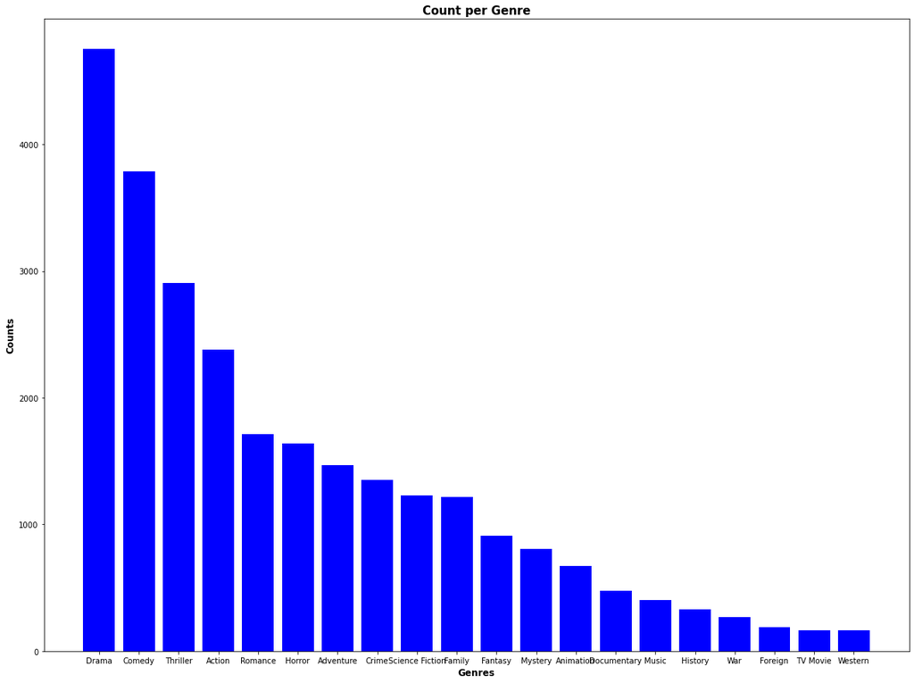

```python
# Count the number of movies in each Genre.
movies_gen_count = genres_df['genres'].value_counts()
# creating the bar plot
plt.figure(figsize=[20,15])
plt.bar(movies_gen_count.index,movies_gen_count.values , color ='blue'
       )

plt.xlabel("Genres",fontsize =12,weight="bold")
plt.ylabel("Counts",fontsize =12,weight="bold")
plt.title("Count per Genre",fontsize =15,weight="bold")
plt.show()
```

Drama has the highest number of movies followed by Comedy

### Bivariate Exploration

```python
# group exploded dataframe by genres, get average popularity
genres_df.groupby('genres').popularity.mean()
```

```
genres
Action             0.927389
Adventure          1.155783
Animation          0.880759
Comedy             0.593553
Crime              0.744930
Documentary        0.187389
Drama              0.592279
Family             0.791718
Fantasy            0.997366
Foreign            0.192131
History            0.580344
Horror             0.465357
Music              0.489556
Mystery            0.690832
Romance            0.592082
Science Fiction    1.003017
TV Movie           0.270896
Thriller           0.742004
War                0.732346
Western            0.590615
Name: popularity, dtype: float64
```

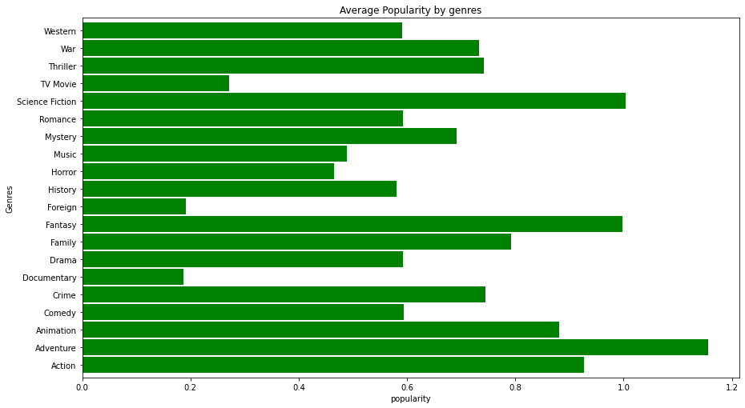

```python
# Groupby genres,get average popularity (or any of the continuous variables) and plot

genres_df.groupby('genres').popularity.mean().plot.barh(color=['g'],width=0.9,figsize=[14.70,8.27],rot=0,title ='Average Popularity by genres')
plt.xlabel('popularity')
plt.ylabel('Genres')
plt.show()
```

Adventure movies has the greatest popularity

### Check for movie genre popularity by decade

```python
# There are a lot of years,so I have created a decade variable,using division(lowest integer divisor)
genres_df ['release_decade']=((genres_df['release_year']//10)*10).astype(int)
#groupby decade and genres,get average popularity,unstack(to move decade to column index)
genres_df.groupby(['genres','release_decade'])['popularity'].mean().unstack()
```

| release_decade genres | 1960 | 1970 | 1980 | 1990 | 2000 | 2010 |
| --- | --- | --- | --- | --- | --- | --- |
| Action | 0.528698 | 0.604557 | 0.687248 | 0.705453 | 0.863660 | 1.349642 |
| Adventure | 0.729339 | 0.794976 | 0.814570 | 0.809803 | 1.044127 | 1.869156 |
| Animation | 0.885228 | 0.664687 | 0.660027 | 1.010729 | 0.820598 | 0.954076 |
| Comedy | 0.413045 | 0.434483 | 0.508643 | 0.549083 | 0.583798 | 0.711171 |
| Crime | 0.474908 | 0.537706 | 0.487522 | 0.775507 | 0.697801 | 0.986525 |
| Documentary | 0.087849 | 0.179876 | 0.191011 | 0.177213 | 0.197587 | 0.184284 |
| Drama | 0.404743 | 0.470929 | 0.457893 | 0.581831 | 0.552920 | 0.722785 |
| Family | 0.583018 | 0.555082 | 0.677136 | 0.658648 | 0.828124 | 0.950322 |
| Fantasy | 0.359747 | 0.582298 | 0.584277 | 0.779828 | 1.141380 | 1.313084 |
| Foreign | 0.236392 | 0.080901 | 0.257391 | 0.179515 | 0.202330 | 0.153584 |
| History | 0.429380 | 0.436797 | 0.452767 | 0.558806 | 0.587795 | 0.740486 |
| Horror | 0.314311 | 0.385690 | 0.412893 | 0.536522 | 0.485685 | 0.471589 |
| Music | 0.509348 | 0.441695 | 0.395576 | 0.502819 | 0.518182 | 0.500395 |
| Mystery | 0.481111 | 0.385518 | 0.369915 | 0.704094 | 0.697082 | 0.888042 |
| Romance | 0.384791 | 0.402422 | 0.464055 | 0.560288 | 0.619202 | 0.681162 |
| Science Fiction | 0.383337 | 0.734403 | 0.711960 | 0.811676 | 0.846898 | 1.528175 |
| TV Movie | 0.564817 | 0.267322 | 0.269475 | 0.227634 | 0.251999 | 0.287699 |
| Thriller | 0.591658 | 0.507987 | 0.557316 | 0.705312 | 0.687828 | 0.911305 |
| War | 0.414410 | 0.504992 | 0.594167 | 0.709656 | 0.757526 | 1.020298 |
| Western | 0.359609 | 0.300856 | 0.304812 | 0.584420 | 0.572248 | 1.425661 |

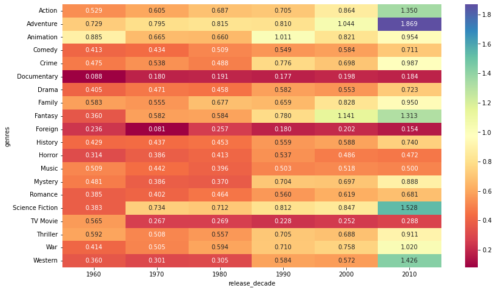

```python
#Set plot dimensions
plt.figure(figsize=[14,8])
dataplot = sns.heatmap(genres_df.groupby(['genres','release_decade'])['popularity'].mean().unstack(), cmap="Spectral", annot =True,fmt=".3f")
#Displaying heatmap
plt.show()
```

### Visualize the relationship between Genre,Decade and Revenue

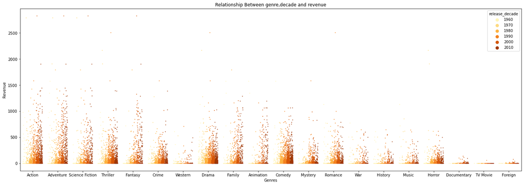

```python
f, g=plt.subplots(figsize=[24,8])
g= sns.stripplot(data=genres_df,y='revenue in million dollar', x='genres',hue='release_decade',palette="YlOrBr",jitter=0.35,dodge=True,size=2)
plt.title('Relationship Between genre,decade and revenue' )
plt.xlabel('Genres',fontsize=10);
plt.ylabel('Revenue',fontsize=10);
```

```python
# Group by Revenue in million Dollar
genres_rev=genres_df.groupby(['genres','release_decade'])['revenue in million dollar'].mean().unstack()
```

```python
genres_df.head()
```

|  | popularity | budget | revenue | original_title | cast | runtime | genres | release_date | vote_count | vote_average | release_year | budget_adj | revenue_adj | budget in million dollar | revenue in million dollar | release_decade |
| --- | --- | --- | --- | --- | --- | --- | --- | --- | --- | --- | --- | --- | --- | --- | --- | --- |
| 0 | 32.985763 | 150000000 | 1513528810 | Jurassic World | Chris Pratt\|Bryce Dallas Howard\|Irrfan Khan\|Vi... | 124 | Action | 6/9/15 | 5562 | 6.5 | 2015 | 1.379999e+08 | 1.392446e+09 | 137.999939 | 1392.445893 | 2010 |
| 0 | 32.985763 | 150000000 | 1513528810 | Jurassic World | Chris Pratt\|Bryce Dallas Howard\|Irrfan Khan\|Vi... | 124 | Adventure | 6/9/15 | 5562 | 6.5 | 2015 | 1.379999e+08 | 1.392446e+09 | 137.999939 | 1392.445893 | 2010 |
| 0 | 32.985763 | 150000000 | 1513528810 | Jurassic World | Chris Pratt\|Bryce Dallas Howard\|Irrfan Khan\|Vi... | 124 | Science Fiction | 6/9/15 | 5562 | 6.5 | 2015 | 1.379999e+08 | 1.392446e+09 | 137.999939 | 1392.445893 | 2010 |
| 0 | 32.985763 | 150000000 | 1513528810 | Jurassic World | Chris Pratt\|Bryce Dallas Howard\|Irrfan Khan\|Vi... | 124 | Thriller | 6/9/15 | 5562 | 6.5 | 2015 | 1.379999e+08 | 1.392446e+09 | 137.999939 | 1392.445893 | 2010 |
| 1 | 28.419936 | 150000000 | 378436354 | Mad Max: Fury Road | Tom Hardy\|Charlize Theron\|Hugh Keays-Byrne\|Nic... | 120 | Action | 5/13/15 | 6185 | 7.1 | 2015 | 1.379999e+08 | 3.481613e+08 | 137.999939 | 348.161292 | 2010 |

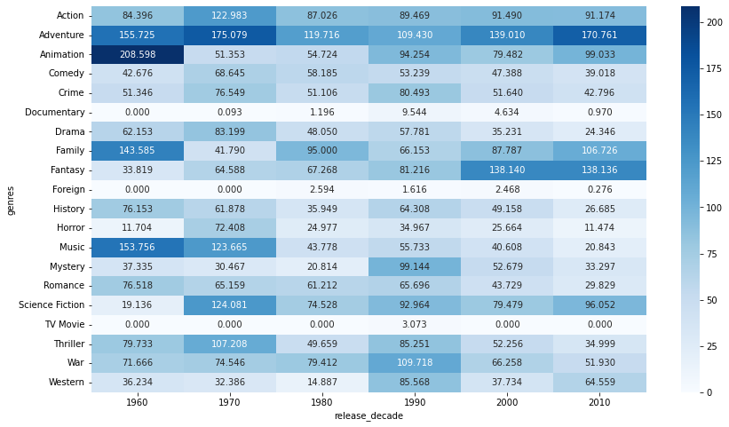

```python
#Set plot dimensions
plt.figure(figsize=[14,8])
dataplot = sns.heatmap(genres_rev, cmap="Blues", annot =True,fmt=".3f")
#Displaying heatmap
plt.show()
```

### Checking Trend in the Movie DataFrame

```python
# Group the columns of interest into categorical and numerical list
numeric_vars = ['vote_count','vote_average', 'budget in million dollar','revenue in million dollar']
categoric_vars = ['genres', 'runtime']
```

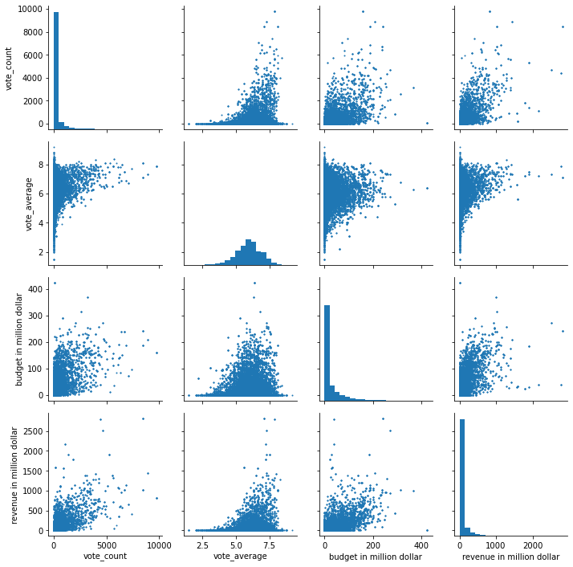

```python
# plot matrix: sample 5000 movies to get a clearer plot and faster rendering

samples = np.random.choice(genres_df.shape[0],5000, replace = False)
movie_samp = genres_df.iloc[samples,:]

g = sns.PairGrid(data = genres_df, vars = numeric_vars)
g = g.map_diag(plt.hist, bins = 20);
g.map_offdiag(plt.scatter,s=1);
```

There is a fairly strong positive correlation between Revenue,Vote count and Budget.

There are alot of outliers in the revenue,budget and vote average in the movie dataset.

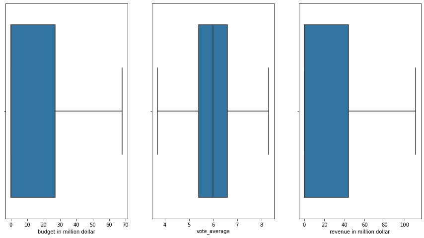

```python
#We will use ignore outlier function in seaborn to remove the outlier in order to get a more accurate summary statistics
plt.figure(figsize=[15,8])

plt.subplot(1,3,1)
sns.boxplot(data= genres_df, x='budget in million dollar',showfliers = False, orient='x');

plt.subplot(1,3,2)
sns.boxplot(data= genres_df, x='vote_average',showfliers = False, orient='x');

plt.subplot(1,3,3)
sns.boxplot(data= genres_df , x='revenue in million dollar',showfliers = False, orient='x');
```

There is no distinct median line in the budget and revenue because the median must have coincide with quartiles of the column.

### Multivariate Visualization

I want to see the relationship between genre,budget,revenue and release decade.

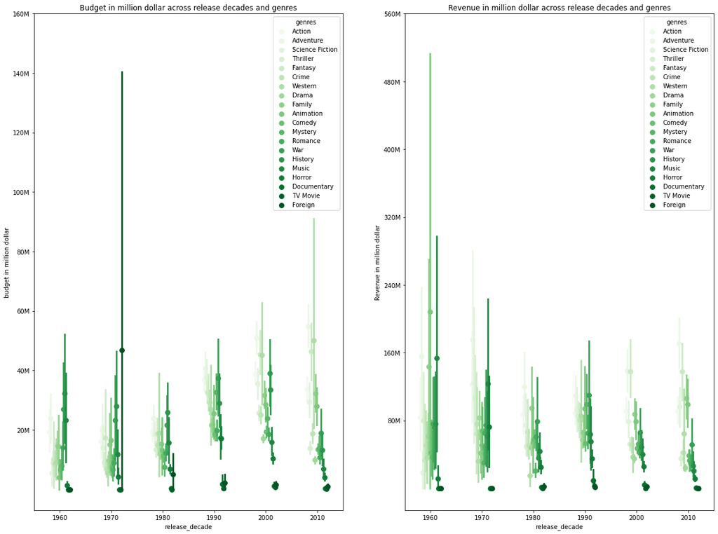

```python
fig, ax = plt.subplots(ncols = 2, figsize = [20,15])

sns.pointplot(data = genres_df, x ='release_decade' , y = 'budget in million dollar', hue = 'genres',
             palette = 'Greens', linestyles = '', dodge = 0.4, ax = ax[0])
ax[0].set_title('Budget in million dollar across release decades and genres')
ax[0].set_ylabel('budget in million dollar')
ax[0].set_yticks([20,40,60,80,100,120,140,160])
ax[0].set_yticklabels(['20M','40M','60M','80M','100M','120M','140M','160M'])
ax[0].set_yticklabels([],minor = True)

sns.pointplot(data = genres_df, x = 'release_decade', y = 'revenue in million dollar', hue = 'genres',
             palette = 'Greens', linestyles = '', dodge = 0.4, ax = ax[1])
ax[1].set_title('Revenue in million dollar across release decades and genres')
ax[1].set_ylabel('Revenue in million dollar')
ax[1].set_yticks([80,160,240,320,400,480,560])
ax[1].set_yticklabels(['80M','160M','240M','320M','400M','480M','560M'])
ax[1].set_yticklabels([],minor = True)
plt.show();
```

The budget for Foreign movie shows a spike in 1970s,but gradually shows a decline as the years goes by.